# Network Analysis

A network is a set of objects (nodes) with interconnections (edges). Networks are all around us. These include

- Social networks
- Co-authorship networks
- Transportation networks
- Biological networks
- Technological
- Trade networks
- Financial networks

## Applications

- Social Sciences: Influence, communities, diffusion.
- Biology: Gene/protein interaction networks.
- Computer Science: Web search (PageRank), security.
- Marketing: Viral campaigns, recommendation systems.
- Finance: Interbank lending, systemic risk.
- Epidemiology: Disease tracking with contact graphs.

## Overview

This note will discuss networks and network types, examine methods to read network data, explore and visualize network graphs and take a deep dive into network metrics.

```python
import numpy as np
import pandas as pd
import matplotlib.pyplot as plt
import networkx as nx
import nxviz as nv
from networkx.algorithms import community
import warnings
warnings.filterwarnings('ignore')
```

## Simple Network

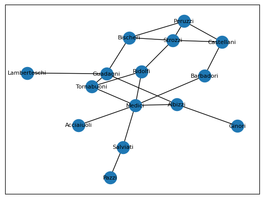

```python
G = nx.florentine_families_graph()
nx.draw_networkx(G, font_size = 8)
```

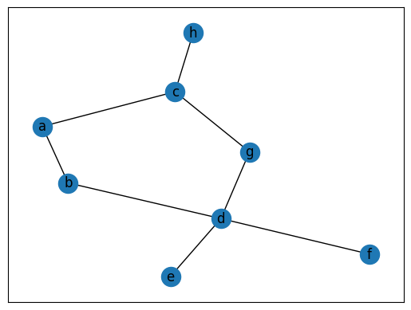

```python
G = nx.Graph()
G.add_edges_from([('a','b'),
                  ('a','c'),
                  ('b','d'),
                  ('c','g'),
                  ('d','e'),
                  ('d','f'),
                  ('d','g'),
                  ('c','h')])
nx.draw_networkx(G)
```

## Network Types

- Undirected: Edges have no direction.
- Directed: Edges have direction (e.g., Twitter).
- Weighted: Edges carry numeric weights.
- Signed: Edges indicate positive or negative relations.
- Multigraphs: Multiple edges between node pairs.
- Bipartite: Two distinct node sets (e.g., authors and papers).
  - Projection: One-mode graph from bipartite structure.

### Undirected Network

Edges do not have a direction.

```python
type(nx.Graph())
```

```
networkx.classes.graph.Graph
```

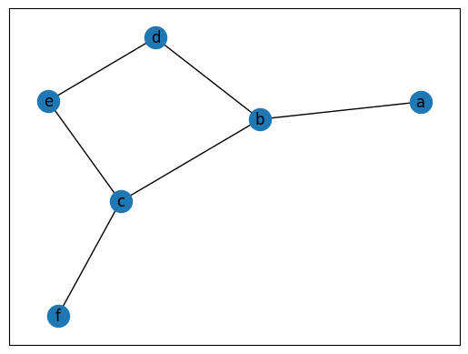

```
<class 'networkx.classes.graph.Graph'>
```

```python
G_undirected = nx.Graph([('a', 'b'),
                         ('b', 'c'),
                         ('b','d'),
                         ('c', 'e'),
                         ('d', 'e'),
                         ('c','f')])
pos = nx.spring_layout(G_undirected, seed = 617)
nx.draw_networkx(G_undirected, pos = pos)
plt.show()
print(type(G_undirected))
```

### Directed Network

Edges have direction.

```python
type(nx.DiGraph())
```

```
networkx.classes.digraph.DiGraph
```

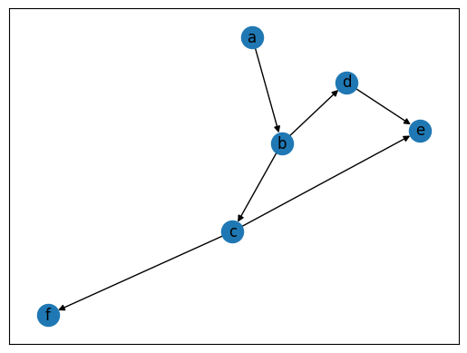

```
<class 'networkx.classes.digraph.DiGraph'>
```

```python
G_directed = nx.DiGraph([('a', 'b'),
                         ('b', 'c'),
                         ('b','d'),
                         ('c', 'e'),
                         ('d', 'e'),
                         ('c','f')])
pos = nx.spring_layout(G_directed,seed = 617)
nx.draw_networkx(G_directed,pos = pos)
plt.show()
print(type(G_directed))
```

### Weighted Network

Not all relationships are equal. Some edges carry more weight than others.

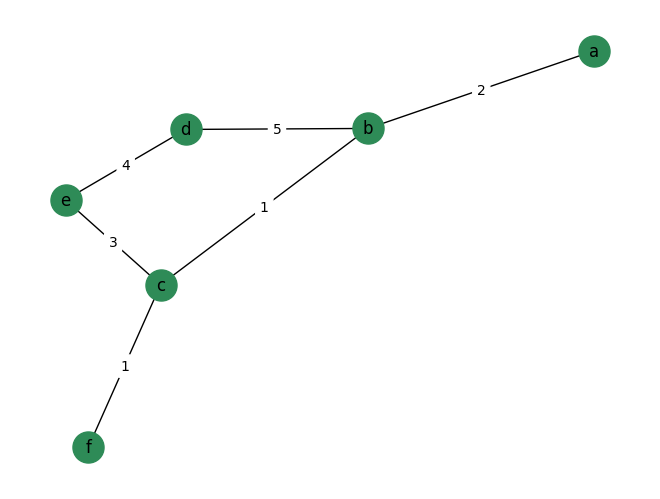

```python
G_weighted = nx.Graph()
G_weighted.add_weighted_edges_from([('a','b', 2),
                                    ('b','c', 1),
                                    ('b','d', 5),
                                    ('c','e', 3),
                                    ('d','e', 4),
                                    ('c','f', 1)])
pos = nx.spring_layout(G_weighted, seed = 617)
nx.draw(G_weighted, pos, with_labels=True, node_color='seagreen', node_size=500)
labels = nx.get_edge_attributes(G_weighted, 'weight')
nx.draw_networkx_edge_labels(G_weighted, pos, edge_labels=labels,rotate = False)
plt.show()
```

### Signed Network

Relationships between nodes may differ in valence only such as friends and foes.

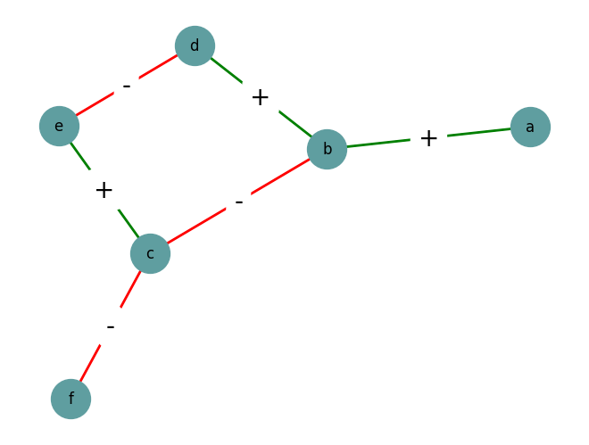

```python
G = nx.Graph()
edges = [('a','b', '+'),
         ('b','c', '-'),
         ('b','d', '+'),
         ('c','e', '+'),
         ('d','e', '-'),
         ('c','f', '-')]
for u, v, sign in edges:
    G.add_edge(u, v, sign=sign)

pos = nx.spring_layout(G, seed=617)
nx.draw(G,
        pos,
        with_labels=True,
        node_color="cadetblue",
        node_size=1000)

for u, v, d in G.edges(data=True):
    color = "green" if d["sign"] == "+" else "red"
    nx.draw_networkx_edges(G,
                           pos,
                           edgelist=[(u, v)],
                           edge_color=color,
                           width=2)

labels = nx.get_edge_attributes(G, "sign")
nx.draw_networkx_edge_labels(G, pos, edge_labels=labels,font_size=20,rotate=False)
plt.show()
```

### Other Edge Attributes

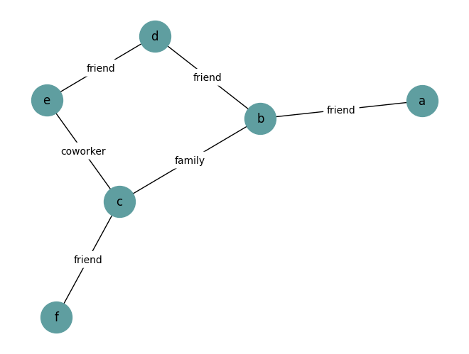

```python
edges = [('a', 'b', 'friend'),
         ('b', 'c','family'),
         ('b','d', 'friend'),
         ('c', 'e', 'coworker'),
         ('d', 'e', 'friend'),
         ('c','f', 'friend')]
G = nx.Graph()
for u, v, relation in edges:
    G.add_edge(u,v,relation = relation)
pos = nx.spring_layout(G, seed=617)
nx.draw(G,
        pos,
        with_labels=True,
        node_color="cadetblue",
        node_size=1000)
labels = nx.get_edge_attributes(G, "relation")
nx.draw_networkx_edge_labels(G,
                             pos,
                             edge_labels=labels,
                             font_size=10,
                             rotate=False)
plt.show()
```

### Multigraph

A pair of nodes can have different types of relationships simultaneously

```python
type(nx.MultiGraph()), type(nx.MultiDiGraph())
```

```
(networkx.classes.multigraph.MultiGraph,
 networkx.classes.multidigraph.MultiDiGraph)
```

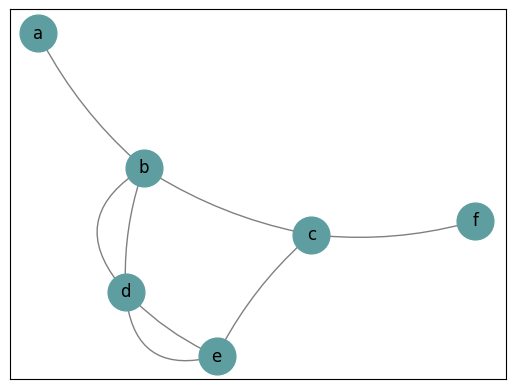

```python
edges = [('a', 'b', 'friend'),
         ('b', 'c','family'),
         ('b','d', 'friend'),
                  ('b','d', 'family'),
         ('c', 'e', 'coworker'),
         ('d', 'e', 'friend'),
                  ('d', 'e', 'family'),
         ('c','f', 'friend')]
G = nx.MultiGraph()
for u, v, relation in edges:
    G.add_edge(u,v,relation = relation)
pos = nx.spring_layout(G, seed=1)

nx.draw_networkx_nodes(G, pos, node_color="cadetblue", node_size=700)
nx.draw_networkx_labels(G, pos)
# Draw all edges with curvature and label each one
for i, (u, v, key, data) in enumerate(G.edges(keys=True, data=True)):
    nx.draw_networkx_edges(
        G, pos,
        edgelist=[(u, v)],
        connectionstyle=f"arc3,rad={(0.1 + 0.5 * key)}",
        edge_color="gray"
    )
plt.show()
```

### Bipartite Graph

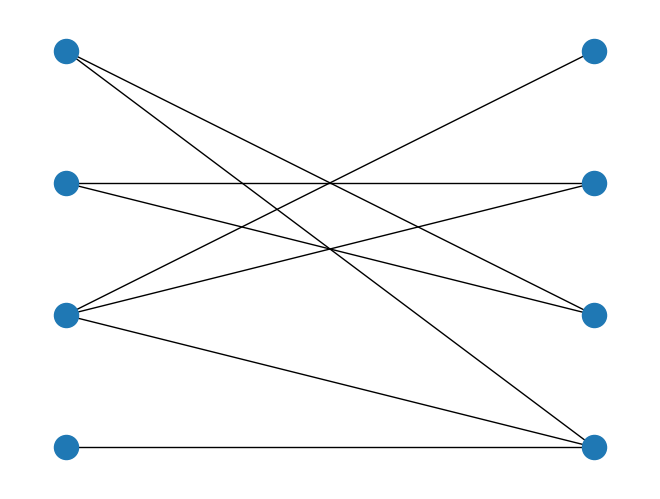

```python
from networkx.algorithms import bipartite
G = bipartite.random_graph(4, 4, 0.5,seed = 61710)
nx.draw(G, pos = nx.bipartite_layout(G,nodes = [0,1,2,3]))
```

## Read Network Data

#### Edge list

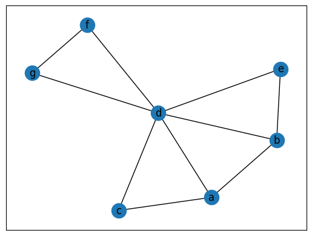

```python
G = nx.read_edgelist('edge_list.txt',delimiter=' ')
nx.draw_networkx(G)
plt.show()
```

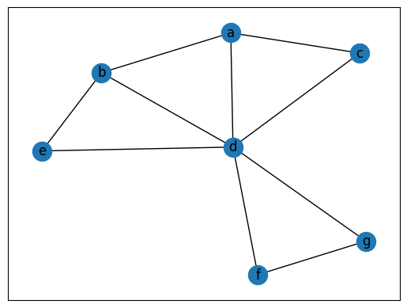

```python
df = pd.read_csv('edge_list.csv',header=None, names=['x','y'])
G = nx.from_pandas_edgelist(df,'x','y')
nx.draw_networkx(G)
plt.show()
```

#### Adjacency List

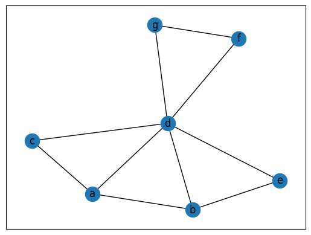

```python
G = nx.read_adjlist('adjacency_list.txt')
nx.draw_networkx(G)
```

## Explore and Visualize Network Graph

```python
G = pd.read_pickle('major_us_cities')
```

Edges and Nodes

```python
len(G.nodes()), len(G.edges())
```

```
(51, 235)
```

```python
city_nodes = G.nodes(data = True)
list(city_nodes)[:5]
```

```
[('El Paso, TX', {'population': np.int64(674433), 'location': (-106, 31)}),
 ('Long Beach, CA', {'population': np.int64(469428), 'location': (-118, 33)}),
 ('Dallas, TX', {'population': np.int64(1257676), 'location': (-96, 32)}),
 ('Oakland, CA', {'population': np.int64(406253), 'location': (-122, 37)}),
 ('Albuquerque, NM', {'population': np.int64(556495), 'location': (-106, 35)})]
```

```python
city_edges = G.edges(data = True)
list(city_edges)[:5]
```

```
[('El Paso, TX', 'Albuquerque, NM', {'weight': 367.88584356108345}),
 ('El Paso, TX', 'Mesa, AZ', {'weight': 536.256659972679}),
 ('El Paso, TX', 'Tucson, AZ', {'weight': 425.41386739988224}),
 ('El Paso, TX', 'Phoenix, AZ', {'weight': 558.7835703774161}),
 ('El Paso, TX', 'Colorado Springs, CO', {'weight': 797.7517116740046})]
```

```python
G['El Paso, TX']
```

```
AtlasView({'Albuquerque, NM': {'weight': 367.88584356108345}, 'Mesa, AZ': {'weight': 536.256659972679}, 'Tucson, AZ': {'weight': 425.41386739988224}, 'Phoenix, AZ': {'weight': 558.7835703774161}, 'Colorado Springs, CO': {'weight': 797.7517116740046}})
```

```python
G.degree('El Paso, TX')
```

```
5
```

```python
list(G.neighbors('El Paso, TX'))
```

```
['Albuquerque, NM',
 'Mesa, AZ',
 'Tucson, AZ',
 'Phoenix, AZ',
 'Colorado Springs, CO']
```

```python
G.edges['El Paso, TX','Albuquerque, NM']
```

```
{'weight': 367.88584356108345}
```

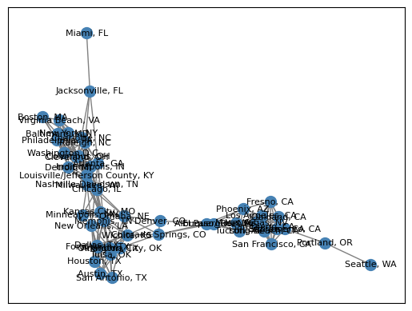

```python
nx.draw_networkx(G, font_size = 8,node_size = 100, node_color ='steelblue', edge_color = 'grey')
plt.show()
```

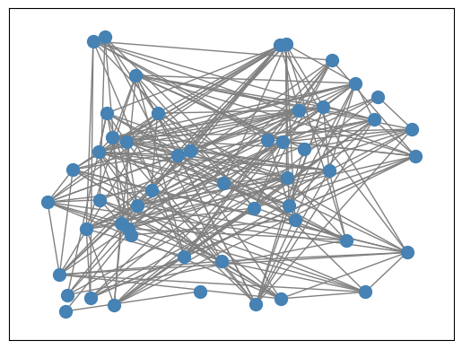

```python
nx.draw_networkx(G,
                 pos = nx.random_layout(G),
                 with_labels = False,
                 font_size = 8,
                 node_size = 100,
                 node_color ='steelblue',
                 edge_color = 'grey')
```

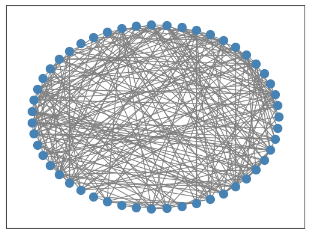

```python
nx.draw_networkx(G,
                 pos = nx.circular_layout(G),
                 with_labels = False,
                 font_size = 8,
                 node_size = 100,
                 node_color ='steelblue',
                 edge_color ='grey')
```

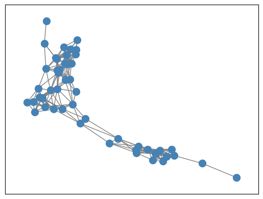

```python
nx.draw_networkx(G,
                 pos = nx.spring_layout(G),
                 with_labels = False,
                 font_size = 8,
                 node_size = 100,
                 node_color ='steelblue',
                 edge_color ='grey')
```

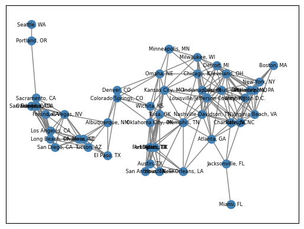

```python
nx.draw_networkx(G,
                 pos = nx.get_node_attributes(G, 'location'),
                 font_size = 6,
                 node_size = 100,
                 node_color ='steelblue',
                 edge_color = 'grey')
```

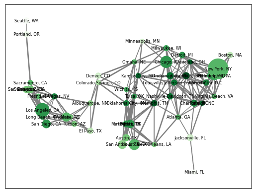

```python
node_color = [G.degree(v) for v in G]
node_size = [0.0001*nx.get_node_attributes(G, 'population')[v] for v in G]
edge_width = [0.0025*G[u][v]['weight'] for u,v in G.edges()]
nx.draw_networkx(G,
                 pos = nx.get_node_attributes(G, 'location'),
                 font_size = 6,
                 node_size = node_size,   # reflects population
                 node_color = node_color, # reflects degree
                 edge_color = 'grey',
                 width = edge_width,      # reflects weight
                 cmap = plt.cm.Greens)
plt.show()
```

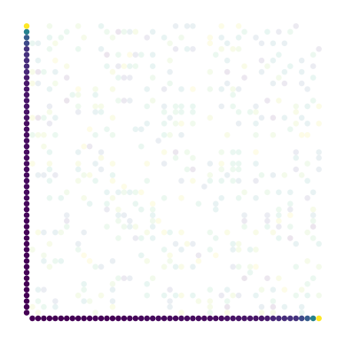

```python
nv.matrix(G,edge_color_by='weight', node_color_by='population', sort_by='population')
plt.show()
```

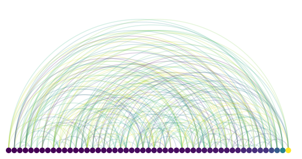

```python
nv.arc(G,edge_color_by='weight', node_color_by='population', sort_by='population')
plt.show()
```

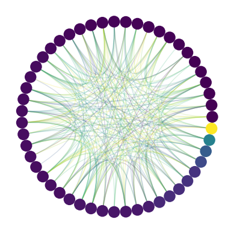

```python
nv.circos(G,edge_color_by='weight', node_color_by='population', sort_by='population')
plt.show()
```

## Network Metrics

### Distance Measures

Distance reflects how far apart nodes are. Distance metrics help understand how information or influence may travel through the network and how accessible nodes are.

```python
edges = [
    ('Alice', 'Bob'), ('Alice', 'Claire'),
    ('Bob', 'Eve'),  ('Claire', 'Grace'),
    ('David', 'Helen'), ('Eve', 'Ivan'), ('Frank', 'Grace'),
    ('Grace', 'Jack'), ('Helen', 'Kevin'), ('Ivan', 'Lily'),
    ('Jack', 'Mona'), ('Kevin', 'Nina'), ('Lily', 'Mona'), ('Mona','Frank'),('Mona','Eve'),('Mona','Alice'),
    ('Nina', 'Oscar'), ('Oscar', 'Claire'), ('Oscar', 'David')
]
G = nx.Graph()
G.add_edges_from(edges)
nx.draw(G,
        pos = nx.spring_layout(G, seed = 1031),
        with_labels=True,
        node_color='steelblue',
        edge_color='gray',
        node_size=800,
        font_size=8)
plt.show()
```

#### Pairwise Distances

- Shortest Path is the distance between two nodes is the length of the shortest path between them
- Eccentricity of a node n is the largest distance between n and all other nodes

```python
nx.shortest_path(G,'Ivan','Grace')
```

```
['Ivan', 'Eve', 'Mona', 'Jack', 'Grace']
```

```python
nx.shortest_path_length(G,'Ivan','Grace')
```

```
4
```

```python
nx.eccentricity(G, 'Ivan')
```

```
7
```

#### Summarizing all Distances in a Network

Find distance from a node to every other node. This can be done by the breadth-first search which is a systematic and effcient procedure for computing distances from a node to all other nodes by “discovering” nodes in layers. From this one can compute distances in a network.  
- Average Distance: Average of all pairwise distances between nodes  
- Diameter: Maximum distance between any pair of nodes  
- Radius: The minimum eccentricity in the graph

```python
nx.average_shortest_path_length(G)
```

```
3.019047619047619
```

```python
nx.diameter(G)
```

```
7
```

```python
nx.radius(G)
```

```
4
```

#### Central and Peripheral Nodes

- Periphery is the set of nodes with eccentricity = diameter
- Center is the set of nodes with eccentricity = radius

```python
nx.periphery(G)
```

```
['Helen', 'Ivan', 'Kevin']
```

```python
nx.diameter(G)
```

```
7
```

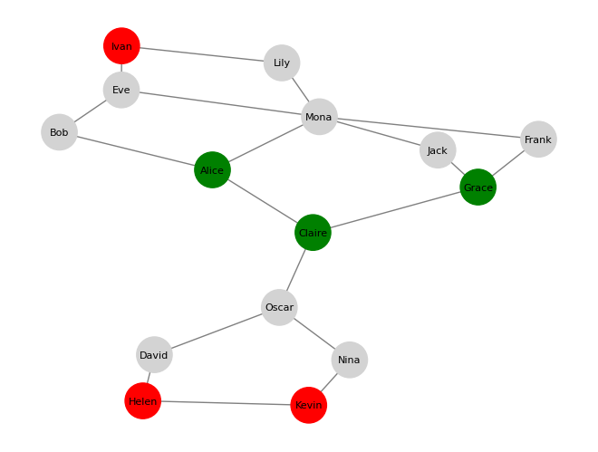

```python
G = nx.Graph()
G.add_edges_from(edges)

node_colors = []
for node in G.nodes():
    if node in set(nx.center(G)):
        node_colors.append('green')       # Center nodes
    elif node in set(nx.periphery(G)):
        node_colors.append('red')         # Periphery nodes
    else:
        node_colors.append('lightgray')   # Neither

nx.draw(G,
        pos = nx.spring_layout(G, seed = 1031),
        with_labels=True,
        node_color=node_colors,
        edge_color='gray',
        node_size=800,
        font_size=8)

plt.show()
```

### Triadic Closure or Clustering

Triadic closure is the tendency for people who share connections in a social network to become connected. In other words, the new edges that appear in a network are likely to be the ones that close triangles “a friend of a friend is likely to become a friend”

Clustering Coefficient is a formal way of measuring triadic closure.

- Local Clustering Coefficient: Defined for a single node
  - High local clustering coefficient indicates the node is embedded in a tightly knit group
- Global Clustering Coefficient: Aggregate measure over the entire graph
  - Average clustering coefficient: Unweighted average of all local clustering coefficients
  - Transitivity: Degree weighted average of all local clustering coefficients
  - A network with high global clustering tends to form communities and exhibits social cohesion

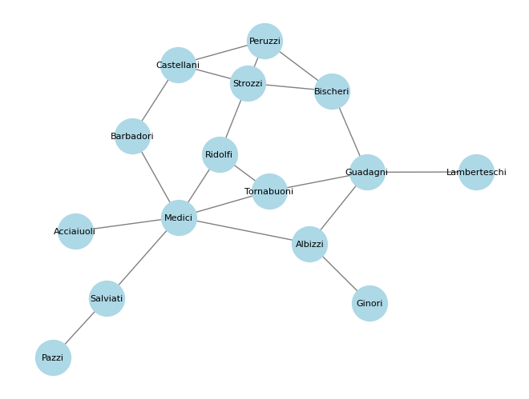

```python
G = nx.florentine_families_graph()
nx.draw(G,
        pos = nx.spring_layout(G, seed = 1031),
        with_labels=True,
        node_color='lightblue',
        edge_color='gray',
        node_size=1000,
        font_size=8)
plt.show()
```

```python
nx.clustering(G)
```

```
{'Acciaiuoli': 0,
 'Medici': 0.06666666666666667,
 'Castellani': 0.3333333333333333,
 'Peruzzi': 0.6666666666666666,
 'Strozzi': 0.3333333333333333,
 'Barbadori': 0,
 'Ridolfi': 0.3333333333333333,
 'Tornabuoni': 0.3333333333333333,
 'Albizzi': 0,
 'Salviati': 0,
 'Pazzi': 0,
 'Bischeri': 0.3333333333333333,
 'Guadagni': 0,
 'Ginori': 0,
 'Lamberteschi': 0}
```

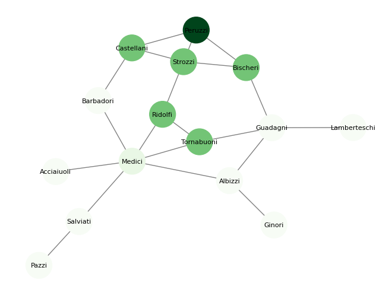

```python
G = nx.florentine_families_graph()
nx.draw(G,
        pos = nx.spring_layout(G, seed = 1031),
        with_labels=True,
        node_color=nx.clustering(G).values(),
        edge_color='gray',
        node_size=1000,
        font_size=8,
        cmap = plt.cm.Greens)
plt.show()
```

```python
nx.average_clustering(G)
```

```
0.16
```

```python
nx.transitivity(G)
```

```
0.19148936170212766
```

### Centrality

Centrality in network analysis refers to quantitative measures used to identify the most important, influential, or strategically positioned nodes within a network.

- in social networks, central individuals can influence opinion, spread information, or broker resources
- in transportation networks, central nodes may serve as hubs or bottlenecks
- in technological networks, centrality can identify vulnerable computers or routers

We will examine four centrality measures that differ on the assumptions they make about what it means to be “central”.

- Degree Centrality: Number of connections a node has
- Closeness Centrality: The inverse of the average shortest path from a node to all other nodes. Measures how quickly information can spread from that node.
- Betweenness Centrality: Measures how often a node appears on the shortest paths between other pairs of nodes. These nodes serve as bridges.
- Page Rank: Considers quality of connections.

```python
edges = [
    ('Alice', 'Bob'), ('Alice', 'Claire'),
    ('Bob', 'Eve'),  ('Claire', 'Grace'),
    ('David', 'Helen'), ('Eve', 'Ivan'), ('Frank', 'Grace'),
    ('Grace', 'Jack'), ('Helen', 'Kevin'), ('Ivan', 'Lily'),
    ('Jack', 'Mona'), ('Kevin', 'Nina'), ('Lily', 'Mona'), ('Mona','Frank'),('Mona','Eve'),('Mona','Alice'),
    ('Nina', 'Oscar'), ('Oscar', 'Claire'), ('Oscar', 'David')
]
G = nx.Graph()
G.add_edges_from(edges)
nx.draw(G,
        pos = nx.spring_layout(G, seed = 1031),
        with_labels=True,
        node_color='steelblue',
        edge_color='gray',
        node_size=800,
        font_size=8)
plt.show()
```

#### Degree Centrality

Number of direct connections to a node. It assumes important nodes have many connections. For directed networks, one can compute in-degree or out-degree centrality.

Calculated as degree/(n-1). This can be computed by counting connections to other nodes (called neighbors) and dividing by n-1.

```python
claire_neighbors = list(G.neighbors('Claire'))
claire_neighbors
```

```
['Alice', 'Grace', 'Oscar']
```

```python
len(claire_neighbors)/(len(G.nodes())-1)
```

```
0.21428571428571427
```

```python
# [len(list(G.neighbors(n)))/(len(G.nodes())-1) for n in G.nodes()]
nx.degree_centrality(G)
```

```
{'Alice': 0.21428571428571427,
 'Bob': 0.14285714285714285,
 'Claire': 0.21428571428571427,
 'Eve': 0.21428571428571427,
 'Grace': 0.21428571428571427,
 'David': 0.14285714285714285,
 'Helen': 0.14285714285714285,
 'Ivan': 0.14285714285714285,
 'Frank': 0.14285714285714285,
 'Jack': 0.14285714285714285,
 'Kevin': 0.14285714285714285,
 'Lily': 0.14285714285714285,
 'Mona': 0.3571428571428571,
 'Nina': 0.14285714285714285,
 'Oscar': 0.21428571428571427}
```

#### Closeness Centrality

Reciprocal of the sum of distances to all other nodes. It assumes that important nodes are close to other nodes.

```python
nx.closeness_centrality(G,
                        wf_improved=True)  # This is to adjust the measure for situations with more than one component
                                           # Does not impact a graph with a single component
```

```
{'Alice': 0.4375,
 'Bob': 0.34146341463414637,
 'Claire': 0.45161290322580644,
 'Eve': 0.32558139534883723,
 'Grace': 0.3888888888888889,
 'David': 0.30434782608695654,
 'Helen': 0.25,
 'Ivan': 0.25925925925925924,
 'Frank': 0.358974358974359,
 'Jack': 0.358974358974359,
 'Kevin': 0.25,
 'Lily': 0.3111111111111111,
 'Mona': 0.4117647058823529,
 'Nina': 0.30434782608695654,
 'Oscar': 0.3888888888888889}
```

#### Betweenness Centrality

Proportion of shortest paths that pass through a node. This metric captures the idea that important nodes connect other nodes. Thus, it reflects a node’s control over communication between others.

```python
nx.betweenness_centrality(G,
                          normalized = True)  # To control for graph size. Large graphs with many nodes will have high betweenness centrality measures.
```

```
{'Alice': 0.36080586080586086,
 'Bob': 0.06410256410256411,
 'Claire': 0.5164835164835165,
 'Eve': 0.10805860805860809,
 'Grace': 0.13736263736263737,
 'David': 0.1208791208791209,
 'Helen': 0.01098901098901099,
 'Ivan': 0.009157509157509158,
 'Frank': 0.02197802197802198,
 'Jack': 0.02197802197802198,
 'Kevin': 0.01098901098901099,
 'Lily': 0.04761904761904763,
 'Mona': 0.32783882783882784,
 'Nina': 0.1208791208791209,
 'Oscar': 0.45054945054945056}
```

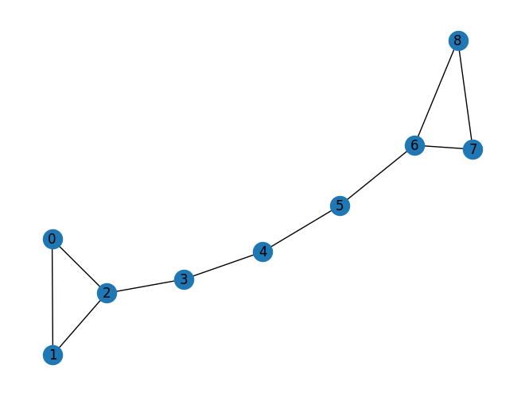

```
{0: 0.0, 1: 0.0, 2: 0.42857142857142855, 3: 0.5357142857142857, 4: 0.5714285714285714, 5: 0.5357142857142857, 6: 0.42857142857142855, 7: 0.0, 8: 0.0}
```

```python
example_graph = nx.barbell_graph(m1 = 3, m2 = 3)
nx.draw(example_graph, with_labels=True)
plt.show()
print(nx.betweenness_centrality(example_graph))
```

#### Page Rank Centrality

Designed by Google co-founders to measure the importance of webpages on the internet based on their interconnections. PageRank assigns an importance score to each node. Important nodes are those with many in-links from other important nodes. It is designed for directed networks.

```python
nx.pagerank(G)
```

```
{'Alice': 0.0735476000676567,
 'Bob': 0.052123557290097405,
 'Claire': 0.07514188429129665,
 'Eve': 0.07512048068200966,
 'Grace': 0.07492474188928047,
 'David': 0.05899955760168569,
 'Helen': 0.06099972861239586,
 'Ivan': 0.053796901822309,
 'Frank': 0.051333824639536514,
 'Jack': 0.051333824639536514,
 'Kevin': 0.06099972861239586,
 'Lily': 0.05296848243184179,
 'Mona': 0.1182703320168996,
 'Nina': 0.05899955760168569,
 'Oscar': 0.08143979780137253}
```

```python
df = pd.DataFrame({
    'Degree': nx.degree_centrality(G),
    'Betweenness': nx.betweenness_centrality(G,normalized=True),
    'Closeness': nx.closeness_centrality(G,wf_improved=True),
    'PageRank': nx.pagerank(G)
})
df.sort_values('Betweenness',ascending = False)
```

|  | Degree | Betweenness | Closeness | PageRank |
| --- | --- | --- | --- | --- |
| Claire | 0.214286 | 0.516484 | 0.451613 | 0.075142 |
| Oscar | 0.214286 | 0.450549 | 0.388889 | 0.081440 |
| Alice | 0.214286 | 0.360806 | 0.437500 | 0.073548 |
| Mona | 0.357143 | 0.327839 | 0.411765 | 0.118270 |
| Grace | 0.214286 | 0.137363 | 0.388889 | 0.074925 |
| David | 0.142857 | 0.120879 | 0.304348 | 0.059000 |
| Nina | 0.142857 | 0.120879 | 0.304348 | 0.059000 |
| Eve | 0.214286 | 0.108059 | 0.325581 | 0.075120 |
| Bob | 0.142857 | 0.064103 | 0.341463 | 0.052124 |
| Lily | 0.142857 | 0.047619 | 0.311111 | 0.052968 |
| Jack | 0.142857 | 0.021978 | 0.358974 | 0.051334 |
| Frank | 0.142857 | 0.021978 | 0.358974 | 0.051334 |
| Helen | 0.142857 | 0.010989 | 0.250000 | 0.061000 |
| Kevin | 0.142857 | 0.010989 | 0.250000 | 0.061000 |
| Ivan | 0.142857 | 0.009158 | 0.259259 | 0.053797 |

### Connected Components

In an undirected graph, a connected component is a group of nodes where:

- Every node is reachable from every other node in the group,
- And no connections exist to nodes outside the group.

In a directed graph, we distinguish between:

- Strongly connected components, where every node can reach and be reached from every other node,
- Weakly connected components, where reachability ignores direction.

An understanding of connected components in a network can help to

1. Detect isolated groups in social networks or telecommunication networks
2. Analyze network fragmentation
3. Measure reachability

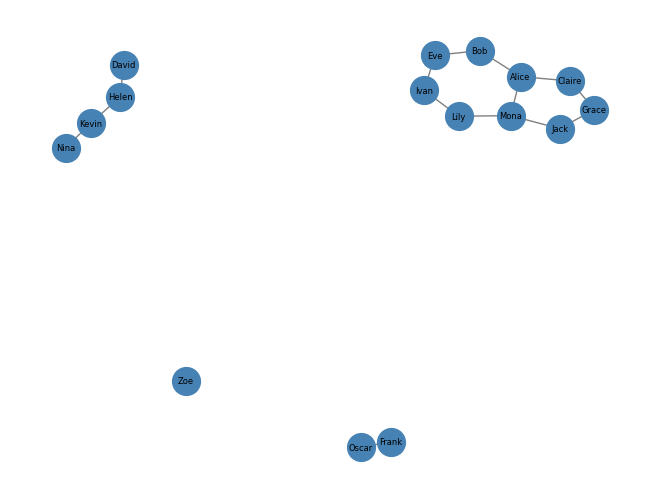

```python
edges = [
    # Component 1
    ('Alice', 'Bob'), ('Alice', 'Claire'),
    ('Bob', 'Eve'),  ('Claire', 'Grace'), ('Eve', 'Ivan'),
    ('Grace', 'Jack'), ('Ivan', 'Lily'), ('Jack', 'Mona'),
    ('Lily', 'Mona'), ('Mona', 'Alice'),

    # Component 2
    ('David', 'Helen'), ('Helen', 'Kevin'), ('Kevin', 'Nina'),

    # Component 3
    ('Oscar', 'Frank'),

    # Isolated node
]

# Build the graph
G = nx.Graph()
G.add_edges_from(edges)
G.add_node('Zoe')  # isolated node

nx.draw(G,
        pos = nx.spring_layout(G,seed = 617),
        with_labels=True,
        node_color='steelblue',
        edge_color='gray',
        node_size=400,
        font_size=6)
plt.show()
```

```python
nx.is_connected(G)
```

```
False
```

```python
nx.number_connected_components(G)
```

```
4
```

```python
nx.connected_components(G)
```

```
<generator object connected_components at 0x00000253B9388D00>
```

```python
nx.node_connected_component(G,'Alice')
```

```
{'Alice', 'Bob', 'Claire', 'Eve', 'Grace', 'Ivan', 'Jack', 'Lily', 'Mona'}
```

### Communities

Groups of nodes that are more densely connected to each other than to the rest of the network.

- Nodes within the same community are highly interconnected.
- Nodes in different communities have fewer or weaker connections between them.

In social networks, communities may reflect friendships, professional groups, or common interests.

Modularity which ranges from -1 to +1 measures density of links inside communities compared to links between communities. Communities can be identified using modularity maximization.

```python
edges = [
    ('Alice', 'Bob'), ('Alice', 'Claire'),
    ('Bob', 'Eve'),  ('Claire', 'Grace'),
    ('David', 'Helen'), ('Eve', 'Ivan'), ('Frank', 'Grace'),
    ('Grace', 'Jack'), ('Helen', 'Kevin'), ('Ivan', 'Lily'),
    ('Jack', 'Mona'), ('Kevin', 'Nina'), ('Lily', 'Mona'), ('Mona','Frank'),('Mona','Eve'),('Mona','Alice'),
    ('Nina', 'Oscar'), ('Oscar', 'Claire'), ('Oscar', 'David')
]
G = nx.Graph()
G.add_edges_from(edges)
from networkx.algorithms.community import greedy_modularity_communities
communities = greedy_modularity_communities(G)
communities
```

```
[frozenset({'Claire', 'David', 'Helen', 'Kevin', 'Nina', 'Oscar'}),
 frozenset({'Alice', 'Bob', 'Eve', 'Ivan', 'Lily'}),
 frozenset({'Frank', 'Grace', 'Jack', 'Mona'})]
```

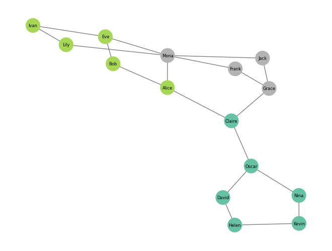

```python
color_map = {}
for i, community in enumerate(communities):
    for node in community:
        color_map[node] = i
colors = [color_map[node] for node in G.nodes]
nx.draw(G,
        pos = nx.spring_layout(G,seed = 617),
        with_labels=True,
        node_color=colors,
        edge_color='gray',
        node_size=400,
        font_size=6,
        cmap = plt.cm.Set2)
plt.show()
```

### Link Prediction

Link prediction aims to estimate the likelihood that a link will form between two nodes that are not currently connected, based on the existing network structure. Link prediction metrics:

- Common Neighbors counts number of mutual friends two nodes share
- Jaccard coefficient normalizes common neighbors by total number of neighbors
- Preferential attachment assumes that those with high degree centrality are more likely to connect

Useful in predicting friends in social networks, collaborators in professional networks, or co-authorships in academic networks.

```python
edges = [
    ('Alice', 'Bob'), ('Alice', 'Claire'),
    ('Bob', 'Eve'),  ('Claire', 'Grace'),
    ('David', 'Helen'), ('Eve', 'Ivan'), ('Frank', 'Grace'),
    ('Grace', 'Jack'), ('Helen', 'Kevin'), ('Ivan', 'Lily'),
    ('Jack', 'Mona'), ('Kevin', 'Nina'), ('Lily', 'Mona'), ('Mona','Frank'),('Mona','Eve'),('Mona','Alice'),
    ('Nina', 'Oscar'), ('Oscar', 'Claire'), ('Oscar', 'David')
]
G = nx.Graph()
G.add_edges_from(edges)
nx.draw(G,
        pos = nx.spring_layout(G, seed = 1031),
        with_labels=True,
        node_color='steelblue',
        edge_color='gray',
        node_size=800,
        font_size=8)
plt.show()
```

#### Common Neighbors

counts number of mutual friends two nodes share

```python
nx.common_neighbors(G, 'Claire','Mona')
```

```
{'Alice'}
```

```python
nx.common_neighbors(G, 'Eve','Lily')
```

```
{'Ivan', 'Mona'}
```

```python
neighbors = [(e[0], e[1], len(nx.common_neighbors(G,e[0],e[1]))) for e in nx.non_edges(G)]
df = pd.DataFrame(neighbors, columns=['name1','name2','common_neighbors'])
df = df.set_index(['name1','name2'])
```

#### Jaccard Coefficient

normalizes common neighbors by total number of neighbors

```python
list(nx.jaccard_coefficient(G))[:5]
```

```
[('Grace', 'Ivan', 0.0),
 ('Grace', 'Alice', 0.2),
 ('Grace', 'Oscar', 0.2),
 ('Grace', 'Mona', 0.3333333333333333),
 ('Grace', 'Helen', 0.0)]
```

```python
df['jaccard'] =  [x for name1, name2, x in nx.jaccard_coefficient(G)]
```

#### Preferential attachment

assumes that those with high degree centrality are more likely to connect

```python
list(nx.preferential_attachment(G))[:5]
```

```
[('Grace', 'Ivan', 6),
 ('Grace', 'Alice', 9),
 ('Grace', 'Oscar', 9),
 ('Grace', 'Mona', 15),
 ('Grace', 'Helen', 6)]
```

```python
df['preferential_attachment'] =  [x for name1, name2, x in nx.preferential_attachment(G)]
df.sort_values(['preferential_attachment'], ascending=False).head()
```

| name1 | name2 | common_neighbors | jaccard | preferential_attachment |
| --- | --- | --- | --- | --- |
| Grace | Mona | 2 | 0.333333 | 15 |
| Oscar | Mona | 0 | 0.000000 | 15 |
| Mona | Claire | 1 | 0.142857 | 15 |
|  | Nina | 0 | 0.000000 | 10 |
| Ivan | Mona | 2 | 0.400000 | 10 |

## Summary

This note discussed networks and network types, examined methods to read network data, explored and visualized network graphs and examined network characteristics including Distance, Clustering, Centrality, Connected components, Community and Link Prediction.

This file was generated using Python 3.13.5 on Windows 10 with the following libraries: matplotlib 3.10.3, networkx 3.5, numpy 2.3.1, nxviz 0.7.6, pandas 2.3.0